# Homework 2/3 - Heaps

Nicolas Solomita

17/3/2020

# Homework 2

### Exercise 3

Let’s compare the results of the `test_delete_min` program using Arrays or the two implementations of the Binary Heap.

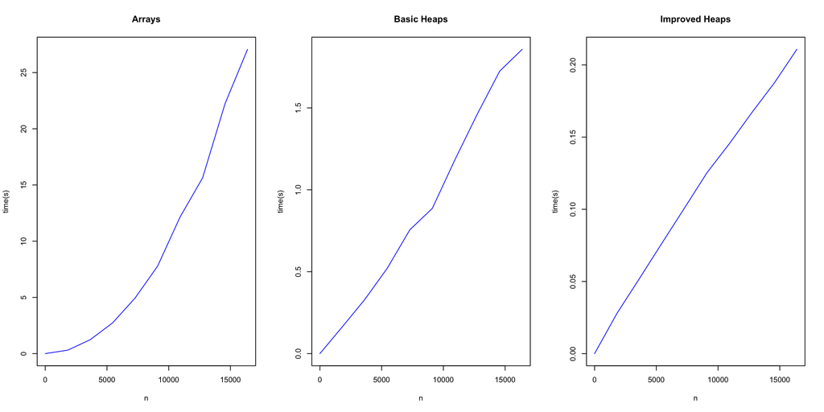

### Exercise 4

Show that, with the array representation, the leaves of a binary heap containing $n$ nodes are indexed by $\lfloor \frac{n}{2} \rfloor + 1$, $\lfloor \frac{n}{2} \rfloor + 2$, . . . $n$.

**Proof**

- The last leaf has index $n$
- The parent of the last leaf has index $\lfloor \frac{n}{2} \rfloor$
- There is no element $x$ s.t. parent(x) has index $\lfloor \frac{n}{2} \rfloor + 1$
- Thus, the leaves are indexed from $\lfloor \frac{n}{2} \rfloor + 1$ to $n$

### Exercise 5

Show that the worst-case running time of HEAPIFY on a binary heap of size n is $\Omega(log n)$. (Hint: For a heap with $n$ nodes, give node values that cause HEAPIFY to be called recursively at every node on a simple path from the root down to a leaf.)

**Proof**

We are showing the proof for a min-heap, but it could be rephrased for any type of heap.

Let a min-heap with $n$ node has the maximum value in the root. If we now call HEAPIFY, we have the worst-case scenario because the procedure will be called at every node on a simple path from the root to a leaf. We know that the heap has height $\Theta(log n)$, therefore the procedure will have a complexity of $\Omega(log n)$.

### Exercise 6

Show that there are at most $\Big\lceil \frac{n}{2^{h +1}} \Big\rceil$ nodes of height $h$ in any $n$-element binary heap.

**Proof**

Let $h$ be the height of the heap and $n(h)$ be the number of nodes at height h. Let’s make the proof by induction:

**Base case**: Let’s consider the root. We have $h=\lfloor log n \rfloor$. Therefore,
$$n(h)=n(\lfloor log n \rfloor)=\Big\lceil \frac{n}{2^{\lfloor log n \rfloor +1}} \Big\rceil=1$$
This is true because $\frac{n}{2^{\lfloor log n \rfloor +1}}$ is positive and the denominator $2^{\lfloor log n \rfloor +1} > 2^{log n} = n$.

**Inductive step**: Let’s assume that $n(i) = \Big\lceil \frac{n}{2^{i +1}} \Big\rceil$ with $h=i$. Thus,

$$n(i-1) \leq 2n(i) = 2\Big\lceil \frac{n}{2^{i +1}} \Big\rceil \leq \Big\lceil \frac{n}{2^i} \Big\rceil$$
This is true because each node has at most 2 children and because $2\lceil x \rceil \leq \lceil 2x \rceil$.

# Homework 3

### Exercise 2

Consider the next algorithm:

```
1 def Ex2(A)
2   D <- build(A)
3   while not is_empty(D)
4     extract_min(D)
5   endwhile
6 enddef
```

where $A$ is an array. Compute the time-complexity of the algorithm when:

**1.** build, is_empty $\in \Theta(1)$, extract_min $\in \Theta(|D|)$

- Line 2: $\Theta(1)$
- Line 3: $\Theta(1) * |D| = \Theta(|D|)$
- Line 4: $\sum_{i=0}^{|D|}\Theta(i) = \Theta(|D|^2)$

$T_1(n) \in \Theta(n^2)$

**2.** build $\in \Theta(|A|)$, is_empty $\in \Theta(1)$, extract_min $\in O(log |D|)$;

- Line 2: $\Theta(1)$
- Line 3: $\Theta(1) * |D| = \Theta(|D|)$
- Line 4: $\sum_{i=0}^{|D|}O(log(i)) = O(log|D|!) \approx |D|*log(|D|-1)$

$T_2(n) \in O(nlog(n))$